# Pstat231HW3

## Q3

```r
cor_tt <- tt_train[,sapply(tt_train,is.numeric)] %>%
  correlate()
```

```
##
## Correlation method: 'pearson'
## Missing treated using: 'pairwise.complete.obs'
```

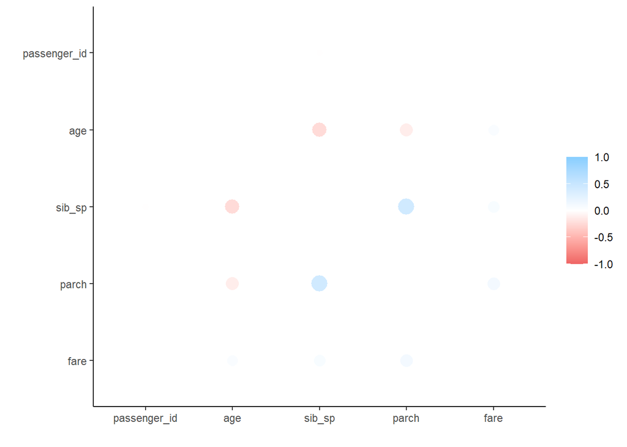

```r
rplot(cor_tt)
```

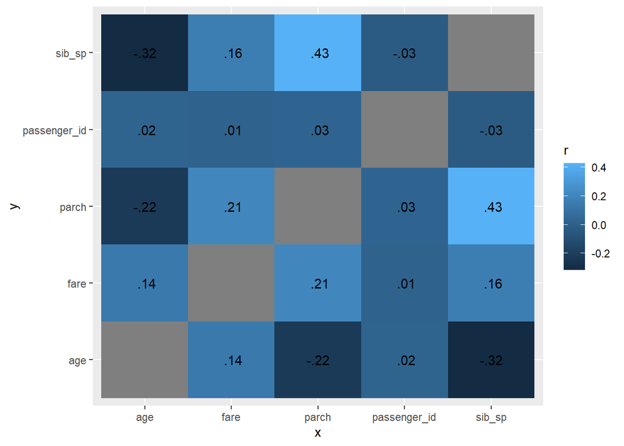

```r
cor_tt %>%
  stretch() %>%
  ggplot(aes(x, y, fill = r)) +
  geom_tile() +
  geom_text(aes(label = as.character(fashion(r))))
```

According to the output. Age is negatively correlated with number of siblings and spouses aboard and number of parents and children aboard. The number of parents and children aboard is positively correlated with number of siblings and spouses aboard and with passenger fare. The fare is also positively correlated with number of siblings and spouses aboard. The rest are weakly correlated or uncorrelated.

## Q4

```r
tt_recipe <- recipe(survived ~ pclass + sex + age +
                           sib_sp + parch + fare, data = tt_train) %>%
  step_impute_linear(age) %>%
  step_dummy(all_nominal_predictors()) %>%
  step_interact(~ starts_with("sex"):fare + age:fare)
```

## Q5

```r
log_reg <- logistic_reg() %>%
  set_engine("glm") %>%
  set_mode("classification")

log_wkflow <- workflow() %>%
  add_model(log_reg) %>%
  add_recipe(tt_recipe)

log_fit <- fit(log_wkflow, tt_train)
```

## Q6

```r
lda_mod <- discrim_linear() %>%
  set_mode("classification") %>%
  set_engine("MASS")

lda_wkflow <- workflow() %>%
  add_model(lda_mod) %>%
  add_recipe(tt_recipe)

lda_fit <- fit(lda_wkflow, tt_train)
```

## Q7

```r
qda_mod <- discrim_quad() %>%
  set_mode("classification") %>%
  set_engine("MASS")

qda_wkflow <- workflow() %>%
  add_model(qda_mod) %>%
  add_recipe(tt_recipe)

qda_fit <- fit(qda_wkflow, tt_train)
```

## Q8

```r
nb_mod <- naive_Bayes() %>%
  set_mode("classification") %>%
  set_engine("klaR") %>%
  set_args(usekernel = FALSE)

nb_wkflow <- workflow() %>%
  add_model(nb_mod) %>%
  add_recipe(tt_recipe)

nb_fit <- fit(nb_wkflow, tt_train)
```

## Q9

```r
log_predict <- predict(log_fit, new_data = tt_train, type = "class")

lda_predict <- predict(lda_fit, new_data = tt_train, type = "class")

qda_predict <- predict(qda_fit, new_data = tt_train, type = "class")

nb_predict <- predict(nb_fit, new_data = tt_train, type = "class")


tt_train_predict <- bind_cols(log_predict, lda_predict, qda_predict, nb_predict, tt_train$survived)


log_reg_acc <- augment(log_fit, new_data = tt_train) %>%
  accuracy(truth = survived, estimate = .pred_class)

lda_acc <- augment(lda_fit, new_data = tt_train) %>%
  accuracy(truth = survived, estimate = .pred_class)

qda_acc <- augment(qda_fit, new_data = tt_train) %>%
  accuracy(truth = survived, estimate = .pred_class)

nb_acc <- augment(nb_fit, new_data = tt_train) %>%
  accuracy(truth = survived, estimate = .pred_class)


accuracies <- c(log_reg_acc$.estimate, lda_acc$.estimate,
                nb_acc$.estimate, qda_acc$.estimate)

models <- c("Logistic Regression", "LDA", "Naive Bayes", "QDA")

results <- tibble(accuracies = accuracies, models = models)
results %>%
  arrange(-accuracies)
```

```
## # A tibble: 4 x 2
##   accuracies models
##        <dbl> <chr>
## 1      0.819 Logistic Regression
## 2      0.796 LDA
## 3      0.775 Naive Bayes
## 4      0.774 QDA
```

According to the output, Logistic Regression achieved the highest accuracy on the training data.

## Q10

```r
predict(log_fit, new_data = tt_test, type = "prob")
```

```
## # A tibble: 179 x 2
##    .pred_Yes .pred_No
##        <dbl>    <dbl>
##  1     0.112    0.888
##  2     0.767    0.233
##  3     0.467    0.533
##  4     0.234    0.766
##  5     0.428    0.572
##  6     0.222    0.778
##  7     0.755    0.245
##  8     0.253    0.747
##  9     0.108    0.892
## 10     0.616    0.384
## # ... with 169 more rows
```

```r
multi_metric <- metric_set(accuracy, sensitivity, specificity)

augment(log_fit, new_data = tt_test) %>%
  multi_metric(truth = survived, estimate = .pred_class)
```

```
## # A tibble: 3 x 3
##   .metric     .estimator .estimate
##   <chr>       <chr>          <dbl>
## 1 accuracy    binary         0.860
## 2 sensitivity binary         0.754
## 3 specificity binary         0.927
```

```r
augment(log_fit, new_data = tt_test) %>%
  conf_mat(truth = survived, estimate = .pred_class)
```

```
##           Truth
## Prediction Yes  No
##        Yes  52   8
##        No   17 102
```

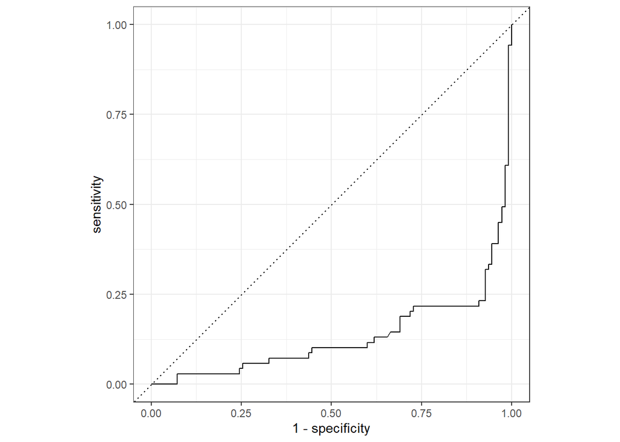

```r
augment(log_fit, new_data = tt_test) %>%
  roc_curve(survived, .pred_No) %>%
  autoplot()
```

```r
augment(log_fit, new_data = tt_test) %>%
  roc_auc(survived, .pred_Yes)
```

```
## # A tibble: 1 x 3
##   .metric .estimator .estimate
##   <chr>   <chr>          <dbl>
## 1 roc_auc binary         0.868
```

Both the accuracy of training and testing are above the 80%, but the accuracy of testing data is little bit higher than the training one. It may caused by the smaller sample size of the testing data.